# Social Media Analytics IV

## 5.2 The mapping

The mapping of a plot is a set of instructions on how parts of the data are mapped onto aesthetic attributes of geometric objects. It is the ‘dictionary’ to translate tidy data to the graphics system.

This simply translated into passing which variables you would like to represent in the graph. This is done by using the function `aes()`. This function must be nested inside the function `ggplot()`.

Let’s use it to tell `ggplot2` that we want to graph the variable `Sepal.Length` as a function of the variable `Petal.Length`:

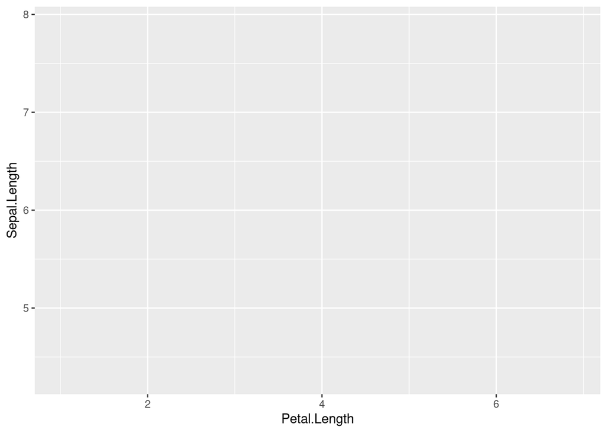

```r
IRIS%>%
  ggplot(aes(x=Petal.Length, y=Sepal.Length))
```

Now, in the “Plots” panel, you can see that in the ‘x-axis’ and the ‘y-axis’, `ggplot2` is representing the variables `Petal.Length` and `Sepal.Length` respectively.

## 5.3 The layers

The layers are made of geometric objects (which we’ll call geoms) and statistical transformations (which we’ll call stats). Geoms represent what you see on the graph: points, lines, polygons, etc. Stats are a summary of the data being observed. You can find a full list of possible objects in the `ggplot2` [Cheat Sheet](https://posit.co/wp-content/uploads/2022/10/data-visualization-1.pdf).

Let’s represent the relation between `Petal.Length` and `Sepal.Length` with points. For this, we must pass the function using the special function **`+`** instead of `%>%`. Then we can use the function `geom_point()`:

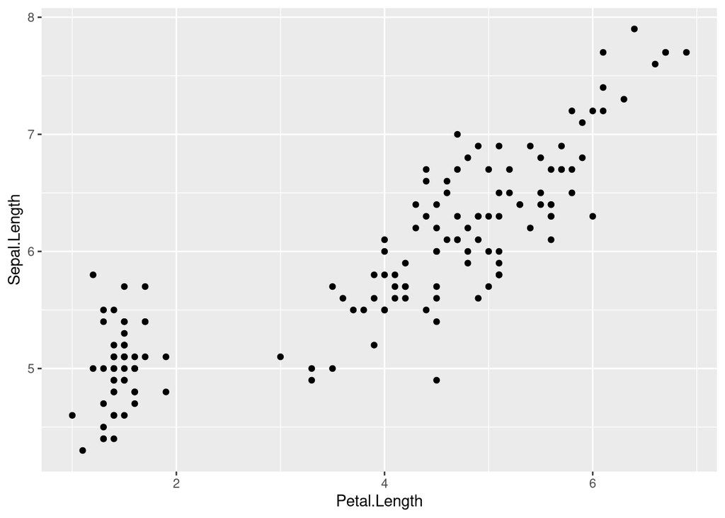

```r
IRIS%>%
  ggplot(aes(x=Petal.Length, y=Sepal.Length))+
  geom_point()
```

## 5.4 The scales

The scales map the values of the data to values in an aesthetic space, such as color, size, or shape. Scales draws the legends or axes, which provides reverse mapping that makes it possible to read the original data from the graph.

Let’s say that you want to color your graph by the `Species` categories. Then, inside the `aes()` function you can pass the “color” scale/parameter:

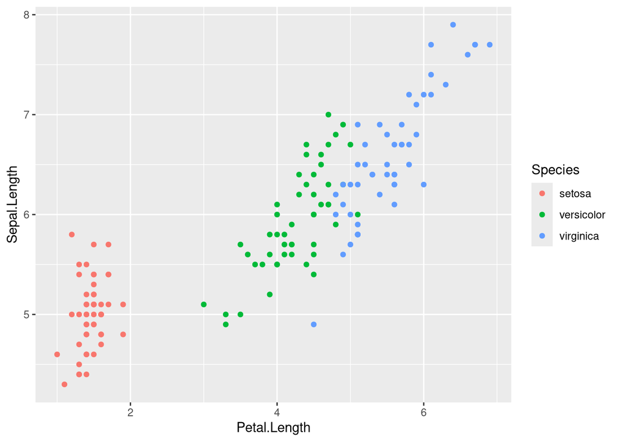

```r
IRIS%>%
  ggplot(aes(x=Petal.Length, y=Sepal.Length, color=Species))+
  geom_point()
```

The types of scales that you can use depend on the geometry. You can check them either in the [Cheat Sheet](https://posit.co/wp-content/uploads/2022/10/data-visualization-1.pdf) or under the “Aesthetics” section of the “Help” panel.

## 5.5 The theme

Themes allows you to exercise fine control over the non-data elements of your plot. The theme system does not affect how the data is rendered by geoms, or how it is transformed by scales. Themes don’t change the perceptual properties of the plot, but they do help you make the plot aesthetically pleasing or match an existing style guide. Themes give you control over things like fonts, ticks, panel strips, and backgrounds.

`ggplot2` offers some predefined themes, such as `theme_bw()` and `theme_light()`. So, we will apply one of them to our graph to make it look better. Remember that in `ggplot2` you add components using the special function `+`:

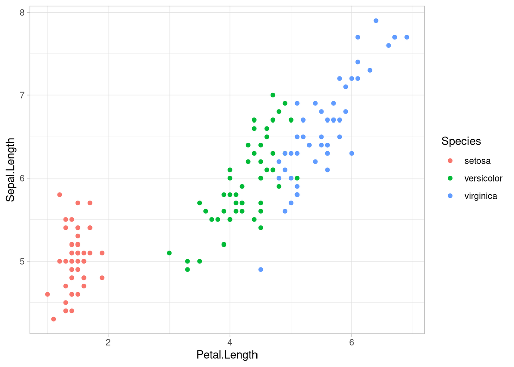

```r
IRIS%>%
  ggplot(aes(x=Petal.Length, y=Sepal.Length, color=Species))+
  geom_point()+
  theme_light()
```

## **Exercise 5**

Now it is your turn to create a `ggplot2` graph. As mentioned before, in the `ggplot2` “Cheat Sheet”, you can check the different geometries together with what scales can be changed depending on the plot.

Using the information in the box “ONE VARIABLE continues”, write the code to produce the following graph:

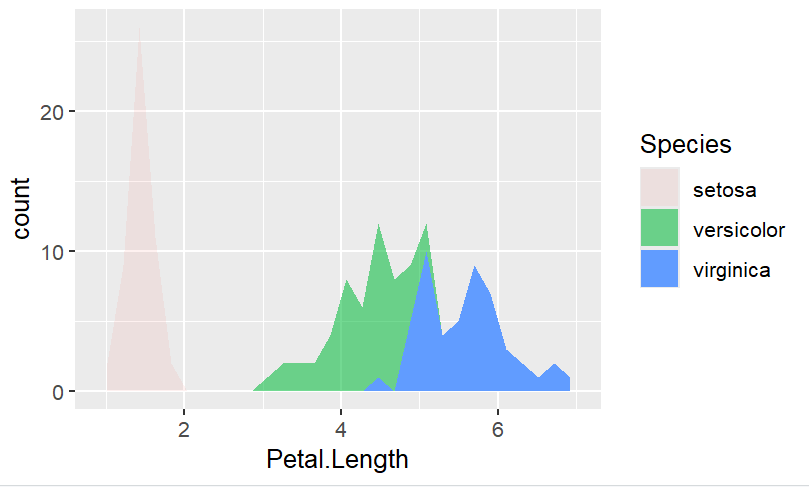

# 6.Text handling with `stringr`

For this section of the tutorial, we will use the `tidyverse` package `stringr` to handle text.

`stringr` is a consistent, simple and easy collection of character string/text/natural language processing tools for pattern searching, random string generation, case mapping, string transliteration, concatenation, sorting, padding, wrapping, and more!

`stringr` offers plenty of functions to work with text ([Cheat Sheet](https://rstudio.github.io/cheatsheets/strings.pdf)) However, we will now only cover the necessary to clean and homogenize the data that we will analyse:

1. `str_remove_all()`
2. `str_replace_all()`
3. `str_to_lower()`
4. `str_squish()`
5. `str_detect()`

In this part of the tutorial, we will use the `sentiment_tweets.csv` dataset. You can find this dataset both in CANVAS and the course JupyterHub environment.

In your R-script save the path to the folder where you stored the data and then open the data in R:

```r
# DIR="PATH TO FOLDER"

TWEETS<-read.csv(paste0(DIR,"sentiment_tweets.csv"), skipNul = TRUE)
```

**Exercise 6:** In your R-script, transform and save your data as a `tibble`. Based on the `tibble`’s information answer the following questions:

1. How many rows and columns does the tibble have?
2. What type of data type are your variables?

## 1. The function `str_remove_all()`

```r
text<-'\" Uneven quotes '

cat(text)
```

```
## " Uneven quotes
```

```r
text<-str_remove_all(text,'\"')

cat(text)
```

```
##  Uneven quotes
```

## 2. The function `str_replace_all()`

Now, we are going to replace any ‘’ (escape character) with an space ” “. A escape character creates a new line when used in the text. For that, we will use the function `str_replace_all()`.

```r
text<-'Escape\n character.\n'

cat(text)
```

```
## Escape
##  character.
```

```r
text<-str_replace_all(text,'\n',' ')

cat(text)
```

```
## Escape  character.
```

**Exercise 6.2:** Apply the function `str_replace_all()` to the column `text` of the tibble. Remember that in order to save the result, you need to save the modified tibble in itself, i.e. in the variable TWEETS. Hint: Use the `dplyr` function `mutate` to save the modified column “text” in itself. Remember that `mutate()` would apply the function `str_replace_all()` to each element of the column `text`.

## 3. The function `str_to_lower()`

The next step is to homogenize the text by turning it into lower case. For this, we use the function `str_to_lower()`:

```r
text<-'ThIs Is A WeIRD Sentence.'

cat(text)
```

```
## ThIs Is A WeIRD Sentence.
```

```r
text<-str_to_lower(text)

cat(text)
```

```
## this is a weird sentence.
```

**Exercise 6.3:** Apply the function `str_to_lower()` to the column `text` of the tibble. Remember that in order to save the result, you need to save the modified tibble in itself, i.e. in the variable TWEETS. Hint: Use the `dplyr` function `mutate` to save the modified column “text” in itself. Remember that `mutate()` would apply the function `str_to_lower()` to each element of the column `text`.

## 4. The function `str_squish()`

This is the final function that we will use to clean the text: `str_squish()`. `str_squish()` trims white space from each end and collapses multiple spaces into single spaces.

```r
text<-'  There   are too   many spaces in this    sentence.  '

cat(text)
```

```
##   There   are too   many spaces in this    sentence.
```

```r
text<-str_squish(text)

cat(text)
```

```
## There are too many spaces in this sentence.
```

**Exercise 6.4:** Apply the function `str_squish()` to the column `text` of the tibble. Remember that in order to save the result, you need to save the modified tibble in itself, i.e. in the variable TWEETS. Hint: Use the `dplyr` function `mutate` to save the modified column “text” in itself. Remember that `mutate()` would apply the function `str_squish()` to each element of the column `text`.

## 5. The function `str_detect()`

This function returns a logic value (`TRUE` or `FALSE`) depending on whether the text contains or not the pattern specified.

```r
text<-'in this text, i write about justin bieber.'

cat(text)
```

```
## in this text, i write about justin bieber.
```

```r
text<-str_detect(text, "bieber")

cat(text)
```

```
## TRUE
```

We can use the function `str_detect()` together with `filter()` to keep only those tweets that mentioned specific words:

```r
BIEBER<-TWEETS%>%
  filter(str_detect(text, "bieber"))
```

Now, we can plot the number of tweets that were positive, neutral, or negative:

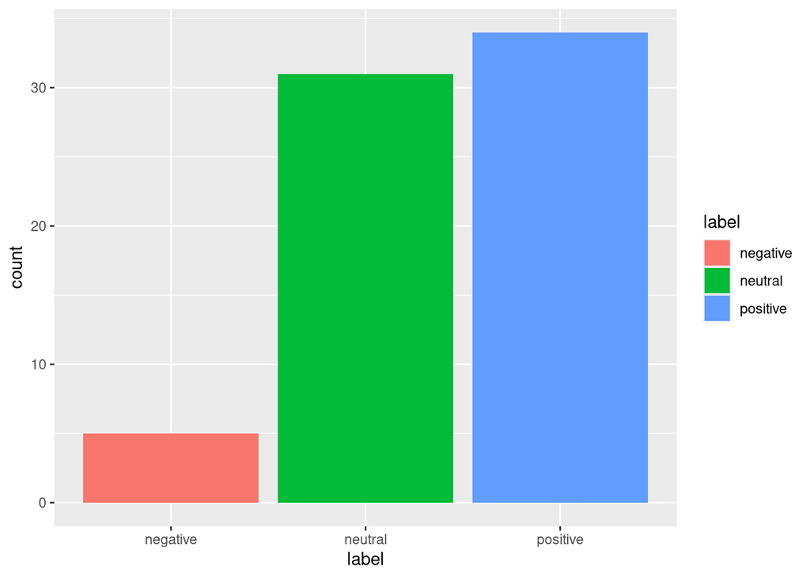

```r
BIEBER%>%
  ggplot(aes(label,fill=label))+
  geom_bar()
```

**Exercise 6.5.a:** Create a barplot showing the number of times the word “trump” was mentioned by label.

**Exercise 6.5.b:** Interpret the results from Exercise 6.5.a.